# Replication of Nordmeyer, Yoon, & Frank, Cogsci 2016

# Initial analysis

## Proportion Correct

Proportion correct:

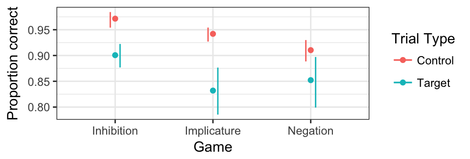

```r
ms.acc <- d %>%
  group_by(game, trial.type, subid) %>%
  summarise(m = mean(correct)) %>%
  group_by(game, trial.type) %>%
  summarise(cih = ci.high(m),
            cil = ci.low(m),
            m = mean(m))

ms.acc$trial.type <- factor(ms.acc$trial.type, labels = c("Control", "Target"))
ms.acc$game <- factor(ms.acc$game, labels = c("Inhibition", "Implicature", "Negation"))


ggplot(data = ms.acc, aes(x = game, y = m, color = trial.type)) +
  geom_point() +
  geom_errorbar(aes(ymin = cil, ymax = cih),
                position = position_dodge(.2), width = 0) +
  geom_line(aes(col = trial.type)) +
  ylab("Proportion correct") + xlab("Game") +
  scale_color_hue(name = "Trial Type") +
  theme_bw()
```

## Reaction time

What about reaction time? Here we just look at RTs on correct trials (outlier RTs were trimmed earlier when the data was loaded).

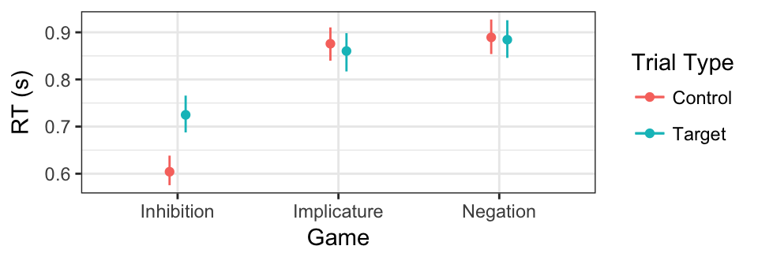

```r
#Plot data
ms.rt <- d %>%
  filter(correct == TRUE) %>%
  group_by(game, trial.type, subid) %>%
  summarise(m = mean(q)) %>%
  group_by(game, trial.type) %>%
  summarise(cih = ci.high(m),
            cil = ci.low(m),
            m = mean(m))

ms.rt$game <- factor(ms.rt$game, labels = c("Inhibition", "Implicature", "Negation"))
ms.rt$trial.type <- factor(ms.rt$trial.type, labels = c("Control", "Target"))

ggplot(data = ms.rt, aes(x = game, y = m, color = trial.type)) +
  geom_point(position = position_dodge(.2)) +
  geom_errorbar(aes(ymin = cil, ymax = cih),
                position = position_dodge(.2), width = 0) +
  geom_line(aes(col = trial.type)) +
  ylab("RT (s)") + xlab("Game") +
  scale_color_hue(name = "Trial Type") +
  theme_bw()
```

## Individual Differences

Is there any correlation between an individual’s performance on one game vs. another game?

First let’s look at individual differences in accuracy for adults:

NOTE: In the cogsci paper, when we calculated the difference scores, we used

```r
mutate(sdiff = scale(target - control))
```

to calculate the difference scores. But for some reason I’m getting an error here where it produces all NaNs. I thought it was because of the bad participants with NAs, but I tried removing them and it still gives me this error.

If I remove scale()it works, so that’s what I’m doing below, both for the accuracy ananlysis and the RT analysis below. Does anyone have thoughts on why this is happening?

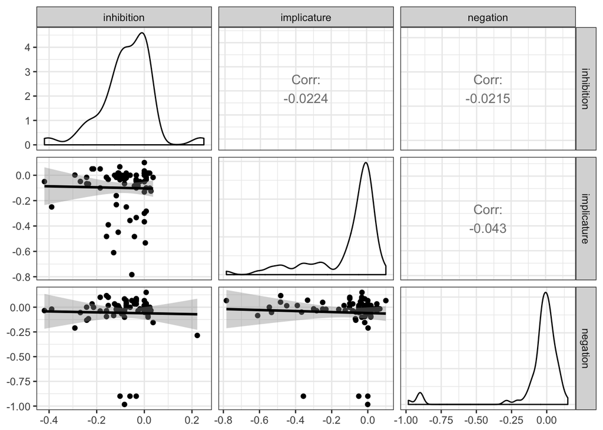

```r
ms.acc.adults <- d %>%
  group_by(subid, game, trial.type) %>%
  summarise(correct = mean(correct)) %>%
  spread(trial.type, correct) %>%
  #mutate(sdiff = scale(target - control)) %>%
  mutate(sdiff = target - control) %>%
  select(-control, -target) %>%
  spread(game, sdiff)

ggpairs(data = ms.acc.adults,
        columns = 2:4,
        upper = list(continuous = "cor"),
        lower = list(continuous = "smooth")) +
  theme_bw()
```

```r
cor.test(ms.acc.adults$inhibition, ms.acc.adults$implicature)
```

```
##
##  Pearson's product-moment correlation
##
## data:  ms.acc.adults$inhibition and ms.acc.adults$implicature
## t = -0.19124, df = 73, p-value = 0.8489
## alternative hypothesis: true correlation is not equal to 0
## 95 percent confidence interval:
##  -0.2480789  0.2056292
## sample estimates:
##         cor
## -0.02237703
```

```r
cor.test(ms.acc.adults$inhibition, ms.acc.adults$negation)
```

```
##
##  Pearson's product-moment correlation
##
## data:  ms.acc.adults$inhibition and ms.acc.adults$negation
## t = -0.18532, df = 74, p-value = 0.8535
## alternative hypothesis: true correlation is not equal to 0
## 95 percent confidence interval:
##  -0.2458003  0.2049122
## sample estimates:
##         cor
## -0.02153839
```

```r
cor.test(ms.acc.adults$negation, ms.acc.adults$implicature)
```

```
##
##  Pearson's product-moment correlation
##
## data:  ms.acc.adults$negation and ms.acc.adults$implicature
## t = -0.36993, df = 74, p-value = 0.7125
## alternative hypothesis: true correlation is not equal to 0
## 95 percent confidence interval:
##  -0.2658438  0.1842772
## sample estimates:
##         cor
## -0.04296329
```

Individual differences in reaction time for adults:

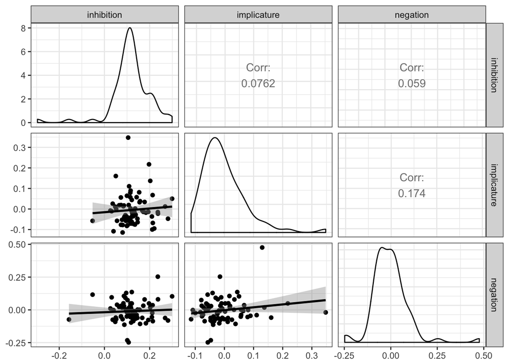

```r
ms.rt.adults <- d %>%
  filter(correct == TRUE) %>%
  group_by(subid, game, trial.type) %>%
  summarise(rt = mean(q)) %>%
  spread(trial.type, rt) %>%
  #mutate(sdiff = scale(target - control)) %>%
  mutate(sdiff = target - control) %>%
  select(-control, -target) %>%
  spread(game, sdiff)

ggpairs(data = ms.rt.adults,
        columns = 2:4,
        upper = list(continuous = "cor"),
        lower = list(continuous = "smooth")) +
  theme_bw()
```

```r
cor.test(ms.rt.adults$inhibition, ms.rt.adults$implicature)
```

```
##
##  Pearson's product-moment correlation
##
## data:  ms.rt.adults$inhibition and ms.rt.adults$implicature
## t = 0.65332, df = 73, p-value = 0.5156
## alternative hypothesis: true correlation is not equal to 0
## 95 percent confidence interval:
##  -0.1533734  0.2980468
## sample estimates:
##        cor
## 0.07624239
```

```r
cor.test(ms.rt.adults$inhibition, ms.rt.adults$negation)
```

```
##
##  Pearson's product-moment correlation
##
## data:  ms.rt.adults$inhibition and ms.rt.adults$negation
## t = 0.50476, df = 73, p-value = 0.6152
## alternative hypothesis: true correlation is not equal to 0
## 95 percent confidence interval:
##  -0.1702656  0.2821604
## sample estimates:
##        cor
## 0.05897527
```

```r
cor.test(ms.rt.adults$negation, ms.rt.adults$implicature)
```

```
##
##  Pearson's product-moment correlation
##
## data:  ms.rt.adults$negation and ms.rt.adults$implicature
## t = 1.5085, df = 73, p-value = 0.1358
## alternative hypothesis: true correlation is not equal to 0
## 95 percent confidence interval:
##  -0.05527922  0.38560948
## sample estimates:
##      cor
## 0.173864
```